# Lab 2 - Exploring Image Data

**The planting of a tree, especially one of the long-living hardwood trees, is a gift which you can make to posterity at almost no cost and with almost no trouble, and if the tree takes root it will far outlive the visible effect of any of your other actions, good or evil.”**

― George Orwell

Members:  
CSE 5324: Shenxiao Mei, Samuel Lefcourt  
CSE 7324: Chenming Cui, Zeqi Guo

## Business Understanding

### Introduction

For this lab we choose a dataset of images of data palm leaves. This is a dataset that has three classifications. There are 470 images fall into the class of brown spots, 1203 images for healthy and 958 images for white scale. Most images are 192x350.

### Goals and Objective

It is an important skill for a gardener to identify if a plant has gone ill. Unlike people, trees don't talk. However, a specialist can give a proper diagnosis for an ill tree by observing its leaves. This is something we can definitely solve in machine learning. Using the data, we will predict if a leaf has brown spots, white scales, or is just healthy. Gardeners will be interested in our work because our learning model can facilitate their work so that they don't have to examine each leaf of the entire tree.

### Measure of Success

Credit to Hadjer Hamaidi, the publisher of this dataset.  
Kaggle Source of this dataset: **https://www.kaggle.com/hadjerhamaidi/date-palm-data**

## Data Preparation

### Data Loading

First we need to load the images into numpy arrays. Images in our dataset are 192 x 350,which are considered to be too large to load. In order to load more efficiently, we will resize the images to 40 x 40.

```python
import os
from os.path import join as pjoin
import cv2
import numpy as np
import pandas as pd
```

```python
#######   use for show pic of resized
# 'b' means brownspot
# 'h' means healthy
# 'w' means white scale

train_dir='data\\palm\\train\\'
test_dir='data\\palm\\test\\'
label_list=['brown spots', 'healthy', 'white scale']
array_of_img=[]
def readDataAndGetLabel(data_dir):
    data=[]
    label=[]
    for img_dir in os.listdir(data_dir):
        each_dir=pjoin(data_dir, img_dir)
        each_label=list(img_dir)[0]
        for img in os.listdir(each_dir):
            img_dir=pjoin(each_dir, img)
            readimg=cv2.resize(cv2.imread(img_dir), (40,40))
            data.append(readimg)
            label.append(each_label)
            array_of_img.append(readimg)
    return data,label

X_train, Y_train=readDataAndGetLabel(train_dir)
X_test, Y_test=readDataAndGetLabel(test_dir)
```

```python
print(len(X_test[0]))
print(len(X_test[0][0]))
print(len(X_test[0][0][0]))
```

```
40
40
3
```

Looking into the image data we convert, we notice that the data is actually a three dimensional array because the image is RGB colored. However, in this lab, we choose to recolor it and make it a grey scale image.

Also, for further data analysis, we need to convert the multi-dimensional data into a 1D data array

```python
X_train_1D=[]
new1D=[]
for i in range(len(X_train)):
    image=[]
    for j in range(len(X_train[i])):
        color=0
        for k in range(len(X_train[i][j])):
            color=X_train[i][j][k][0] * 0.2989 + X_train[i][j][k][1] * 0.5870 + X_train[i][j][k][2] * 0.1140
            image.append(color)
    new1D.append(image)
    X_train_1D.append(X_train[i].flatten())

new1D=np.array(new1D)
print(new1D.shape)
```

```
(2616, 1600)
```

Now, we have converted the dataset into a numpy array. New1D consists of 1600 columns, representing each pixel, and 2616 rows, representing each image. Let's do some visualization for the images to examine the quality. The pictures below depict the three kinds of plants that we have.

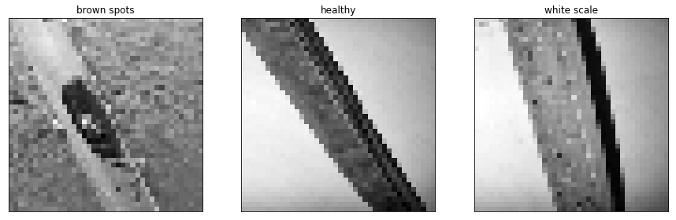

```python
from matplotlib import pyplot as plt
random_brown_id=101
random_healthy_id=801
random_white_id=2001


f, ax = plt.subplots(1, 3, figsize=(15, 15))
plt.subplot(1, 3, 1)
plt.imshow(new1D[random_brown_id].reshape((40,40)),
           cmap=plt.cm.gray)
plt.title('brown spots')
plt.xticks(())
plt.yticks(())
plt.subplot(1, 3, 2)
plt.imshow(new1D[random_healthy_id].reshape((40,40)),
           cmap=plt.cm.gray)
plt.title('healthy')
plt.xticks(())
plt.yticks(())
plt.subplot(1, 3, 3)
plt.imshow(new1D[random_white_id].reshape((40,40)),
           cmap=plt.cm.gray)
plt.title('white scale')
plt.xticks(())
plt.yticks(())
plt.show()
```

They look distinguishable.

## Data Reduction

Now we have finished data preparation, it is time to do dimensional reduction for the data we have got. To represent the data in a lower dimension, we firstly use the Principle Component Analysis.

```python
# manipulated from Sebastian Raschka Example (your book!)
# also from hi blog here: http://sebastianraschka.com/Articles/2015_pca_in_3_steps.html
from sklearn.decomposition import PCA

def plot_explained_variance(pca):
    import plotly
    from plotly.graph_objs import Bar, Line
    from plotly.graph_objs import Scatter, Layout
    from plotly.graph_objs.scatter import Marker
    from plotly.graph_objs.layout import XAxis, YAxis
    plotly.offline.init_notebook_mode() # run at the start of every notebook

    explained_var = pca.explained_variance_ratio_
    cum_var_exp = np.cumsum(explained_var)

    plotly.offline.iplot({
        "data": [Bar(y=explained_var, name='individual explained variance'),
                 Scatter(y=cum_var_exp, name='cumulative explained variance')
            ],
        "layout": Layout(xaxis=XAxis(title='Principal components'), yaxis=YAxis(title='Explained variance ratio'))
    })
```

```python
from sklearn.decomposition import PCA

n_components = 120
pca = PCA(n_components=n_components)
X=new1D
X_pca = pca.fit(X).transform(X)
print ('pca:', pca.components_)
plot_explained_variance(pca)
```

```
pca: [[ 0.03022298  0.02998367  0.02981863 ...  0.02643094  0.0264663
   0.02675302]
 [-0.02141504 -0.02300226 -0.0230513  ... -0.04353878 -0.04222289
  -0.04173938]
 [-0.02946067 -0.0299859  -0.03047254 ...  0.02121059  0.02190919
   0.02146625]
 ...
 [ 0.02314119  0.02912572 -0.00431041 ... -0.02083202 -0.00727816
  -0.01471546]
 [ 0.01442166  0.0117729   0.03212308 ... -0.0029584  -0.01018785
  -0.00018895]
 [-0.03781052 -0.0364051  -0.03068762 ...  0.00652262 -0.014274
  -0.01637988]]
```

[interactive chart not shown]

We choose the amount of principle components to be 120. As the plot shown above, 94% of variance can be represented using 120 components. Then, we will reconstruct the image using 120 components with Full PCA and compare it with the original picture

```python
def reconstruct_image(trans_obj,org_features):
    low_rep = trans_obj.transform(org_features)
    rec_image = trans_obj.inverse_transform(low_rep)
    return low_rep, rec_image
```

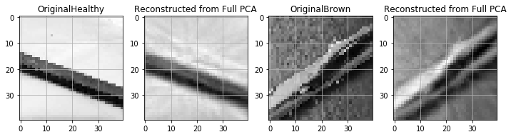

```python
X=np.array(X)
low_dimensional_representation, reconstructed_healthy_pca = reconstruct_image(pca,X[1000].reshape(1, -1))
low_dimensional_representation, reconstructed_brown_pca = reconstruct_image(pca,X[1].reshape(1, -1))
f, ax = plt.subplots(1, 4, figsize=(12, 12))
plt.subplot(1,4,1)
plt.imshow(X[1000].reshape((40, 40)), cmap=plt.cm.gray)
plt.title('OriginalHealthy')
plt.grid()
plt.subplot(1,4,2)
plt.imshow(reconstructed_healthy_pca.reshape((40, 40)), cmap=plt.cm.gray)
plt.title('Reconstructed from Full PCA')
plt.grid()
plt.subplot(1,4,3)
plt.imshow(X[1].reshape((40, 40)), cmap=plt.cm.gray)
plt.title('OriginalBrown')
plt.grid()
plt.subplot(1,4,4)
plt.imshow(reconstructed_brown_pca.reshape((40, 40)), cmap=plt.cm.gray)
plt.title('Reconstructed from Full PCA')
plt.grid()
```

As we can see, the images reconstructed by full PCA still share some features with the original images. However, it is also true that they are blurry and lose some details. Let's take a look at how Kernel PCA performs on reconstruction.

```python
from sklearn.decomposition import KernelPCA

n_components = 100

kpca = KernelPCA(n_components=n_components, kernel='rbf',
                fit_inverse_transform=True, gamma=12, # very sensitive to the gamma parameter,
                remove_zero_eig=True,eigen_solver='arpack')
X=np.array(X)
X_kpca = kpca.fit(X)
```

This Kernel PCA function's paramete eigen_solver default is set to auto. However, it will causes some error "The algorithm failed to convert". Thus I specificly selct arpack as the solver.

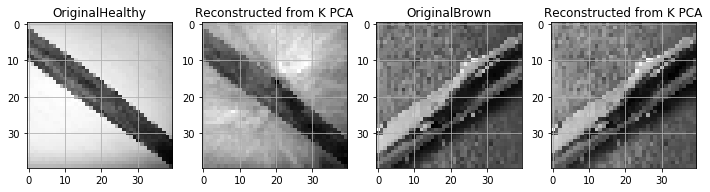

```python
low_dimensional_representation, reconstructed_healthy_xpca = reconstruct_image(X_kpca,X[500].reshape(1, -1))
low_dimensional_representation, reconstructed_brown_xpca = reconstruct_image(X_kpca,X[1].reshape(1, -1))
f, ax = plt.subplots(1, 4, figsize=(12, 12))
plt.subplot(1,4,1)
plt.imshow(X[500].reshape((40, 40)), cmap=plt.cm.gray)
plt.title('OriginalHealthy')
plt.grid()
plt.subplot(1,4,2)
plt.imshow(reconstructed_healthy_xpca.reshape((40, 40)), cmap=plt.cm.gray)
plt.title('Reconstructed from K PCA')
plt.grid()
plt.subplot(1,4,3)
plt.imshow(X[1].reshape((40, 40)), cmap=plt.cm.gray)
plt.title('OriginalBrown')
plt.grid()
plt.subplot(1,4,4)
plt.imshow(reconstructed_brown_xpca.reshape((40, 40)), cmap=plt.cm.gray)
plt.title('Reconstructed from K PCA')
plt.grid()
```

The first reconstructed image have a bad background but the second one is astonishingly good.

We will compare Kernel PCA and full PCA lator both by quantitively later. But first we are going to compare Kernel PCA and full PCA visually

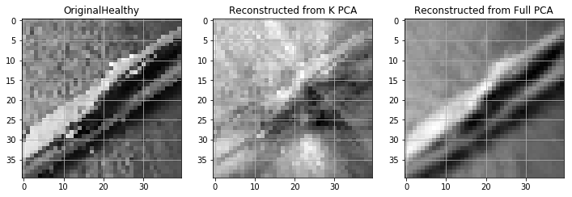

```python
low_dimensional_representation, reconstructed_brown_xpca = reconstruct_image(X_kpca,X[202].reshape(1, -1))
low_dimensional_representation, reconstructed_brown_pca = reconstruct_image(pca,X[202].reshape(1, -1))

f, ax = plt.subplots(2, 3, figsize=(12, 12))
plt.subplot(1,3,1)
plt.imshow(X[202].reshape((40, 40)), cmap=plt.cm.gray)
plt.title('OriginalHealthy')
plt.grid()
plt.subplot(1,3,2)
plt.imshow(reconstructed_brown_xpca.reshape((40, 40)), cmap=plt.cm.gray)
plt.title('Reconstructed from K PCA')
plt.grid()
plt.subplot(1,3,3)
plt.imshow(reconstructed_brown_pca.reshape((40, 40)), cmap=plt.cm.gray)
plt.title('Reconstructed from Full PCA')
plt.grid()
```

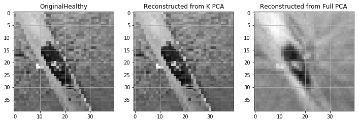

```python
low_dimensional_representation, reconstructed_brown_xpca = reconstruct_image(X_kpca,X[102].reshape(1, -1))
low_dimensional_representation, reconstructed_brown_pca = reconstruct_image(pca,X[102].reshape(1, -1))

f, ax = plt.subplots(2, 3, figsize=(12, 12))
plt.subplot(1,3,1)
plt.imshow(X[102].reshape((40, 40)), cmap=plt.cm.gray)
plt.title('OriginalHealthy')
plt.grid()
plt.subplot(1,3,2)
plt.imshow(reconstructed_brown_xpca.reshape((40, 40)), cmap=plt.cm.gray)
plt.title('Reconstructed from K PCA')
plt.grid()
plt.subplot(1,3,3)
plt.imshow(reconstructed_brown_pca.reshape((40, 40)), cmap=plt.cm.gray)
plt.title('Reconstructed from Full PCA')
plt.grid()
```

In the first set of three images, we can see full PCA almost reconstructs the main features the original image contains. Also, Kernel PCA performs very poorly on reconstructing. The leaf and the background are mixed up and the human eye cannot identify either. However, in the next set of images, while Full PCA still performs to only reconstruct the main feature, Kernel PCA reconstructed so well that one may not be able to identify which is the original. Here we conclude that Kernel PCA can either perform very poorly or performs very well.

Therefore, we need to find an another way to compare the full PCA and Kernel PCA. Next, we are going to use absolute error to quantitatively explain which reconstructing method is better.

```python
sum_pca=0.0
sum_kpca=0.0
for i in range(0,1000):
    low_dimensional_representation, reconstructed_pca = reconstruct_image(pca,X[i].reshape(1, -1))
    low_dimensional_representation, reconstructed_kpca = reconstruct_image(X_kpca,X[i].reshape(1, -1))
    sum_pca+=np.mean(np.absolute(reconstructed_pca.reshape(1,-1)-X[i].reshape(1,-1)))
    sum_kpca+=np.mean(np.absolute(reconstructed_kpca.reshape(1,-1)-X[i].reshape(1,-1)))


print('FULL PCA Average loses:',  sum_pca/1000)
print('Kernel PCA Average loses:', sum_kpca/1000)
```

```
FULL PCA Average loses: 9.56149896371196
Kernel PCA Average loses: 41.68171602687325
```

The average loss is calculated by the mean of absolute error pixel by pixel. We find that full PCA only loses 9.56 and Kernel PCA loses 41.68. This is probably because Kernel PCA is affected by those badly reconstructed images. Therefore, quantitively speaking, Full PCA performs better than Kernel PCA

### Daisy Feature Extraction

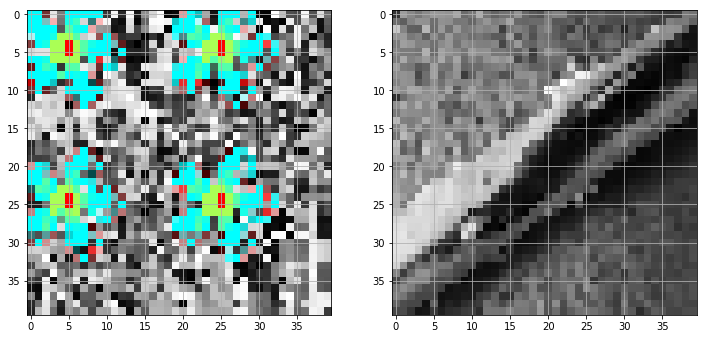

```python
from skimage.feature import daisy

f, ax = plt.subplots(1, 2, figsize=(12, 12))
X=np.array(new1D)
sample_img=X[100].reshape(40,40)
features, img_desc = daisy(sample_img,step=20, radius=5, rings=3, histograms=5, orientations=8, visualize=True)
plt.subplot(1,2,1)
plt.imshow((img_desc * 255).astype(np.uint8))
plt.grid()
plt.subplot(1,2,2)
plt.imshow(X[100].reshape(40,40),cmap=plt.cm.gray)
plt.grid()
```

```python
def apply_daisy(row,shape):
    feat = daisy(row.reshape(shape),step=10, radius=10, rings=2, histograms=6, orientations=8, visualize=False)
    return feat.reshape((-1))

%time test_feature = apply_daisy(X[100],(40,40))
test_feature.shape
```

```
Wall time: 13.8 ms
```

```
(416,)
```

```python
%time daisy_features = np.apply_along_axis(apply_daisy, 1, X, (40,40))
print(daisy_features.shape)
```

```
Wall time: 38.4 s
(2616, 416)
```

From 2616 pictures, we successfully extract 416 features using 38.4 seconds. Now let's find if we can classify the images

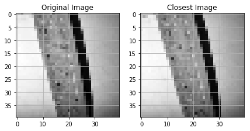

```python
from sklearn.metrics.pairwise import pairwise_distances
dist_matrix = pairwise_distances(daisy_features)
import copy
# find closest image to current image
idx1 = 2000
distances = copy.deepcopy(dist_matrix[idx1,:])
distances[idx1] = np.infty # dont pick the same image!
idx2 = np.argmin(distances)

plt.figure(figsize=(7,10))
plt.subplot(1,2,1)
plt.imshow(X[idx1].reshape((40,40)),cmap=plt.cm.gray)
plt.title("Original Image")
plt.grid()

plt.subplot(1,2,2)
plt.imshow(X[idx2].reshape((40,40)),cmap=plt.cm.gray)
plt.title("Closest Image")
plt.grid()
```

It does find the closest image and that image is itself taken in a different position. That is not good enough to say we can classify the images. Next I am going to visualize the differences between statistics of extracted features in each target class.

```python
df_dist_matrix=pd.DataFrame(data=dist_matrix)
df_dist_matrix.insert(0,column='label', value=Y_train)
df_dist_matrix.head()
```

|  | label | 0 | 1 | 2 | 3 | 4 | 5 | 6 | 7 | 8 | ... | 2606 | 2607 | 2608 | 2609 | 2610 | 2611 | 2612 | 2613 | 2614 | 2615 |
| --- | --- | --- | --- | --- | --- | --- | --- | --- | --- | --- | --- | --- | --- | --- | --- | --- | --- | --- | --- | --- | --- |
| 0 | b | 0.000000 | 0.090191 | 0.099805 | 0.097056 | 0.100038 | 0.097463 | 0.081070 | 0.169610 | 0.093542 | ... | 0.105228 | 0.105012 | 0.159885 | 0.086212 | 0.095123 | 0.082284 | 0.080330 | 0.158863 | 0.077667 | 0.073446 |
| 1 | b | 0.090191 | 0.000000 | 0.078234 | 0.080135 | 0.077496 | 0.078772 | 0.079789 | 0.166706 | 0.076647 | ... | 0.135494 | 0.135106 | 0.153113 | 0.118969 | 0.090858 | 0.116960 | 0.120136 | 0.151175 | 0.115506 | 0.113063 |
| 2 | b | 0.099805 | 0.078234 | 0.000000 | 0.025137 | 0.018398 | 0.021922 | 0.050406 | 0.155103 | 0.023992 | ... | 0.118249 | 0.113266 | 0.157998 | 0.099890 | 0.101230 | 0.102969 | 0.113889 | 0.153092 | 0.110980 | 0.112826 |
| 3 | b | 0.097056 | 0.080135 | 0.025137 | 0.000000 | 0.022051 | 0.020915 | 0.038112 | 0.156590 | 0.019049 | ... | 0.113939 | 0.107839 | 0.160780 | 0.101675 | 0.102258 | 0.103601 | 0.113403 | 0.155906 | 0.111055 | 0.111695 |
| 4 | b | 0.100038 | 0.077496 | 0.018398 | 0.022051 | 0.000000 | 0.020869 | 0.049192 | 0.155347 | 0.023972 | ... | 0.116493 | 0.111322 | 0.161286 | 0.101178 | 0.101599 | 0.103748 | 0.114378 | 0.156208 | 0.111612 | 0.112724 |

5 rows × 2617 columns

```python
df_b = df_dist_matrix[df_dist_matrix.label=='b']
df_h=df_dist_matrix[df_dist_matrix.label=='h']
df_w=df_dist_matrix[df_dist_matrix.label=='w']
df_b=df_b.drop(['label'], axis=1)
df_h.drop(['label'], axis=1)
df_w.drop(['label'], axis=1)
df_b_b=df_b.iloc[:,:465]
df_b_h=df_b.iloc[:,465:1663]
df_b_w=df_b.iloc[:,1663:]
b_b=np.array(df_b_b.values).flatten()
b_h=np.array(df_b_h.values).flatten()
b_w=np.array(df_b_w.values).flatten()
```

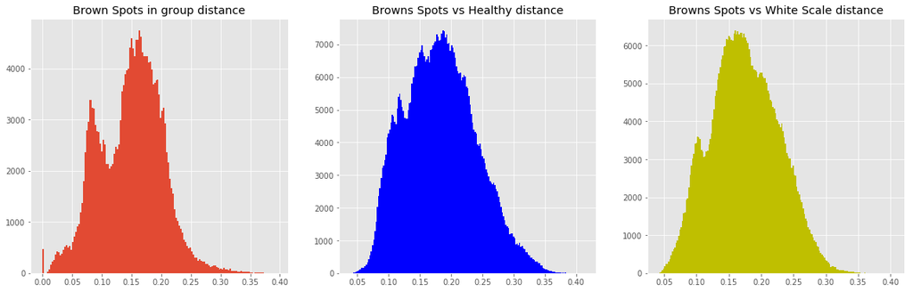

```python
plt.style.use('ggplot')

plt.subplots(1, 3, figsize=(20, 6))
plt.subplot(1,3,1)
plt.hist(b_b, bins='auto')  # arguments are passed to np.histogram
plt.title("Brown Spots in group distance")

plt.subplot(1,3,2)
plt.hist(b_h, bins='auto',color='b')  # arguments are passed to np.histogram
plt.title("Browns Spots vs Healthy distance")

plt.subplot(1,3,3)
plt.hist(b_w, bins='auto',color='y')  # arguments are passed to np.histogram
plt.title("Browns Spots vs White Scale distance")
plt.show()
```

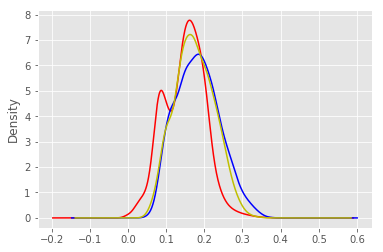

```python
df1=pd.DataFrame(b_b)
df2=pd.DataFrame(b_h)
df3=pd.DataFrame(b_w)
df1.columns=['bb']
df2.columns=['bh']
df3.columns=['bw']
df1.bb.plot.kde(bw_method=0.2,color='r')
df2.bh.plot.kde(bw_method=0.2,color='b')
df3.bw.plot.kde(bw_method=0.2,color='y')
plt.show()
```